# Correlation

Probability Statistics Correlation

## Dataset

We’ll use the `mtcars` datset for this presentation, which contains fuel efficiency information about many cars from 1970.

### Univariate Distribution

For Univariate examples, we will use `mpg`.

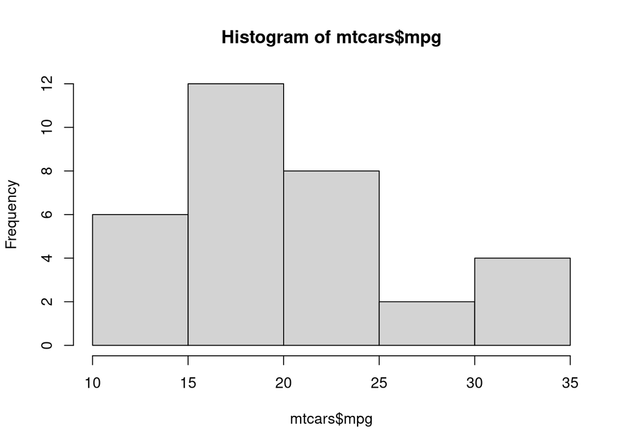

### Bivariate Distributions

For Bivariate examples, we’ll use `mpg`, the miles per gallon; `disp`, the engine displacement; and `hp`, the horsepower of the car.

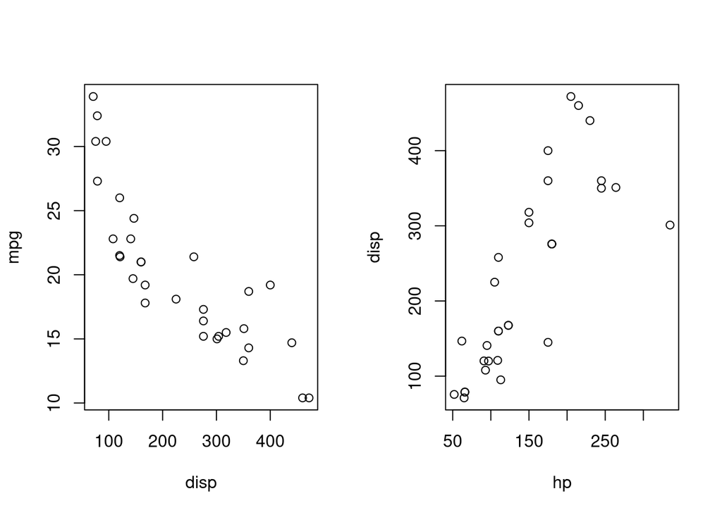

## Variance

When we are considering one variable, we like to use sample variance to measure the “spread” of the data.
$$Var(X) = \sum_{i=1}^n(x_i - \bar{x})^2$$
where $x_i$ is the $i$th case and $\bar{x}$ is the mean of $x_1,...,x_n$.

Standard Deviation might be more familiar, and that is just the square root of the variance
$$SD(X) = \sqrt{\sum_{i=1}^n(x_i-\bar{x})^2}$$

# Covariance

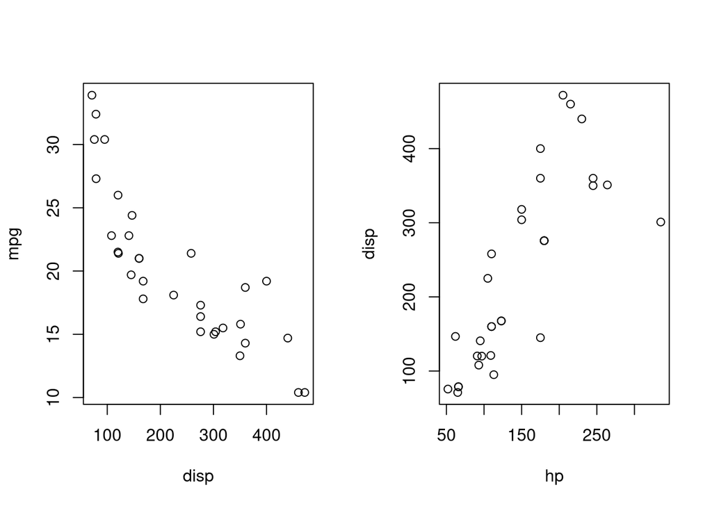

We can see in these plots that the data does not spread evenly in all directions. Instead, the spreads of `mpg`, `disp`, and `hp` affect each other.

We measure how the variables vary *together* with Covariance
$$Cov(X,Y) = \sum_{i=1}^n(x_i-\bar{x})(y_i-\bar{y})$$
$(x_i-\bar{x})$ is the difference between the case $x_i$ and the center $\bar{x}$. Same thing for $(y_i-\bar{y})$.

|  | $y_i < \bar{y}$ | $y_i > \bar{y}$ |
| --- | --- | --- |
| $x_i > \bar{x}$ | $(x_i-\bar{x})(y_i-\bar{y}) < 0$ | $(x_i-\bar{x})(y_i-\bar{y}) > 0$ |
| $x_i < \bar{x}$ | $(x_i-\bar{x})(y_i-\bar{y}) > 0$ | $(x_i-\bar{x})(y_i-\bar{y}) < 0$ |

## Examples

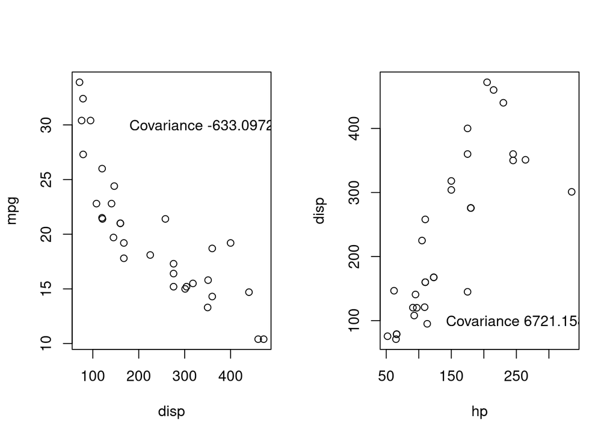

Based on this information, there is much more dependence between `hp` and `disp` than `disp` and `mpg`.

## Issues

The main issue with Covariance as a measure of dependence is that it is tied to the overall spreading of the variables.

Covariance increases (in absolute value) when all of the data is very far from the center, regardless of the relationship between variables.

Correlation scales for the overall spreading in each variable.

# Correlation

## Goals

We want a statistic that

- has its largest (in absolute value) values when the two variables have an exactly linear relationship.
- has some defined limits (-1 and 1) for possible values
- maintains the useful information from Covariance

### Covariance Inequality

There is a very nice property of covariance, that
$$Cov(X,Y) \leq \sqrt{Var(X)}\sqrt{Var(Y)}$$
where $Cov(X,Y) = \sqrt{Var(X)Var(Y)}$ only when $X=Y$.

This is how we come to our formula for correlation:
$$\begin{aligned}
Corr(X,Y) &= \frac{Cov(X,Y)}{\sqrt{Var(X)Var(Y)}} \\
&=
\frac{\sum_{i=1}^n(x_i-\bar{x})(y_i-\bar{y})}{\sqrt{\sum_{i=1}^n(x_i-\bar{x})^2\sum_{i=1}^n(y_i-\bar{y})^2}}
\\
\end{aligned}$$

## Examples

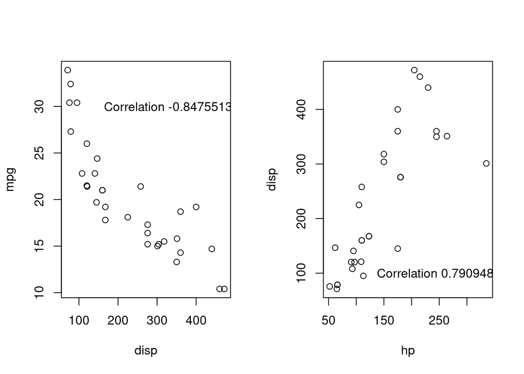

We can see that when accounting for the spread of each variable, the correlations are actually very similar in strength.